# MXB344 Week 5 Slides

23 August 2016

## Welcome

MXB344 Lecture 5

## House Keeping

- Assignment 1 is due 5pm tomorrow. I will be downloading the contents of your github repository then.
- There will be time to discuss last minute queries in today's prac.
  - Also discuss some of the finer points of RMarkdown that may help with presentation.
- The lecture next week will be given over to Dr. Burton Wu from Bank of Queensland who will introduce the context for your second assignment.
  - Definitely and attend and ask thoughtful questions.
- Today I will continue to introduce "Logistic Regression".

## Disambiguation: Binary Regression

### Last Week

- Binary regression assumes the \(Y_{i}\)s follow a Bernoulli distribution. By convention every response is either 0 or 1.
- Overwhelmingly, you will hear this referred to as **Logistic regression**.
  - This comes from the logit function which is the canonical link.
- This regression is probably the second most popular regression in use today after normal.
- Many interesting events can be modelled as Bernoulli:
  - Credit Risk, Survival, Win/Loss of game, Click/Don't click on add, Spam/Ham

## Disambiguation: Binomial Regression

- Assumes the \(Y_{i}\)s follow a Binomial distribution. There are two types of responses which are analogous to the Poisson situation:
  1. \(y_{i}\) from \(n\) trials, where \(n\) is held constant accross each observation (same number of trials).
  2. \(y_{i}\) from \(n_{i}\) trials, where \(n\) varies per observation. This can be rexpressed as modelling \(\pi_{i} = \frac{y_{i}}{n_{i}}\)
- Of these 2 is the most useful.
- Example: Modelling passenger survivorship on the Titanic, proportion exhibiting effect from drug trial group.

## Refresher: Generalised Linear Modelling

How would we model this?

| y | x1 | x2 |
| --- | --- | --- |
| 1 | 0 | 7.5 |
| 0 | 1 | 2.3 |
| 0 | 0 | 1.2 |
| 1 | 1 | 4.1 |

## Example: Binary Exponential Family Derrivation

P83 MAB624 Notes

We consider \(Pr(Y_{i} = y_{i}) = \pi_{i}^{y_{i}}(1-\pi_{i})^{1-y_{i}}\) in exponential family form.

## Example: Binomial Exponential Family Derrivation

The fixed \(n\) cased follows very similar derivation to the binary. We consider the variable \(n\) case.

Using the proprtion \(P_{i} = \frac{Y_{i}}{n_{i}}\) we show the exponential family form of the variable \(n\) case:

\[Pr(P = p) = \frac{1}{n}{n\choose np}\pi^{np}(1-\pi)^{1-y}\]

p85 MAB624 notes

## Intepretation of the Logit

How do we interpret?

\[log\left(\frac{\pi_{i}}{1-\pi_{i}}\right) = \eta_{i}\]

- A common name for \(\frac{\pi}{1-\pi}\) is the **odds ratio** or just plain **odds** .
- The ratio of the probability of an event happening vs not happening.
  - E.g. A horse may be predicted to win a race with 2:1 odds, what does this mean?
- The logit is just the log of this ratio. Called the **log odds**.
- Since \(\frac{\pi}{1-\pi} = \exp(\eta_{i})\) we can interpet our \(\beta\) effects as mutlpliers on the odds ratio when using this link.

## Other Link functions: The Probit

\[\Phi^{-1}(\pi_{i}) = \eta_{i}\]

- In stats notation \(\Phi\) is the CDF of the Normal distribution.
- This link is usually used when the response is a proportion.
- It allows quick computation of a quantity of interest, the **LD50** in dose-repsonse models. \(g(\pi) = \beta_{0} + \beta_{1}x\)
- Can make interpreations of \(\beta\)'s with regards to increases or decreases in the LD50 [Example].

## The Complementary-log-log

\[log(-log(1-\pi_{i})) = \eta_{i} \]

- Often abbreviated to **Cloglog**
- Also associated with dose-response models and proportial responses.
- Has an interpretation in terms of the hazard ratio from survival analysis [Example].
- Rarely used!

## Choosing Link functions

- Choice of these 3 link functions does not usually have a great effect on result.
  - Logit and Probit tend to give very similar results.
  - Cloglog is assymetrical in its tails.
- The choice (between these 3 at least) is usually justified based on what kind of interpretation is desireable.
- More info: [Difference between Probit and Logit Models](http://stats.stackexchange.com/questions/20523/difference-between-logit-and-probit-models)

## Fitting Binary/Binomial Regression

## Example: Challenger Data

| Temp | Pres | Fail | n | Erosion | BlowBy | Damage | Date |
| --- | --- | --- | --- | --- | --- | --- | --- |
| 19 | 50 | 0 | 6 | 0 | 0 | 0 | 4/12/81 |
| 21 | 50 | 1 | 6 | 1 | 0 | 4 | 11/12/81 |
| 21 | 50 | 0 | 6 | 0 | 0 | 0 | 3/22/82 |
| 20 | 50 | 0 | 6 | 0 | 0 | 0 | 11/11/82 |
| 19 | 50 | 0 | 6 | 0 | 0 | 0 | 4/4/83 |
| 22 | 50 | 0 | 6 | 0 | 0 | 0 | 6/18/83 |
| 23 | 50 | 0 | 6 | 0 | 0 | 0 | 8/30/83 |
| 21 | 100 | 0 | 6 | 0 | 0 | 0 | 11/28/83 |
| 14 | 100 | 1 | 6 | 1 | 0 | 4 | 2/3/84 |
| 17 | 200 | 1 | 6 | 1 | 0 | 2 | 4/6/84 |
| 21 | 200 | 1 | 6 | 1 | 0 | 4 | 8/30/84 |
| 26 | 200 | 0 | 6 | 0 | 0 | 0 | 10/5/84 |
| 19 | 200 | 0 | 6 | 0 | 0 | 0 | 11/8/84 |
| 12 | 200 | 2 | 6 | 3 | 2 | 11 | 1/24/85 |
| 19 | 200 | 0 | 6 | 0 | 0 | 0 | 4/12/85 |
| 24 | 200 | 0 | 6 | 0 | 0 | 0 | 4/29/85 |
| 21 | 200 | 0 | 6 | 0 | 0 | 0 | 6/17/85 |
| 27 | 200 | 0 | 6 | 0 | 0 | 0 | 7/29/85 |
| 24 | 200 | 0 | 6 | 0 | 0 | 0 | 8/27/85 |
| 26 | 200 | 0 | 6 | 0 | 0 | 0 | 10/3/85 |
| 24 | 200 | 2 | 6 | 0 | 2 | 4 | 10/30/85 |
| 24 | 200 | 0 | 6 | 0 | 0 | 0 | 11/26/85 |
| 14 | 200 | 1 | 6 | 1 | 0 | 4 | 1/12/86 |

## Exploratory analysis

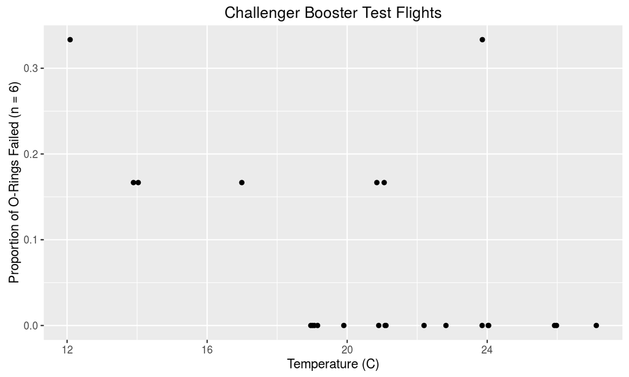

## Fitting Proportional Model

```
##
## Call:
## glm(formula = cbind(Fail, n - Fail) ~ Temp, family = binomial("logit"),
##     data = challenger)
##
## Deviance Residuals:
##      Min        1Q    Median        3Q       Max
## -0.93567  -0.76557  -0.56461  -0.05687   2.67207
##
## Coefficients:
##             Estimate Std. Error z value Pr(>|z|)
## (Intercept)  1.34661    1.59818   0.843   0.3995
## Temp        -0.20673    0.08652  -2.389   0.0169 *
## ---
## Signif. codes:  0 '***' 0.001 '**' 0.01 '*' 0.05 '.' 0.1 ' ' 1
##
## (Dispersion parameter for binomial family taken to be 1)
##
##     Null deviance: 24.230  on 22  degrees of freedom
## Residual deviance: 18.357  on 21  degrees of freedom
## AIC: 35.917
##
## Number of Fisher Scoring iterations: 5
```

## Analysis of Deviance

```r
anova(prop_model, test="Chisq")
```

```
## Analysis of Deviance Table
##
## Model: binomial, link: logit
##
## Response: cbind(Fail, n - Fail)
##
## Terms added sequentially (first to last)
##
##
##      Df Deviance Resid. Df Resid. Dev Pr(>Chi)
## NULL                    22     24.230
## Temp  1   5.8733        21     18.357  0.01537 *
## ---
## Signif. codes:  0 '***' 0.001 '**' 0.01 '*' 0.05 '.' 0.1 ' ' 1
```

## Residuals and Dispersion

```r
sum(residuals(prop_model, type="pearson")^2)
```

```
## [1] 30.76284
```

Dispersion still assumed to be 1 in binomial models, but it is less common to check it.

## Residual Plots

### Pearson

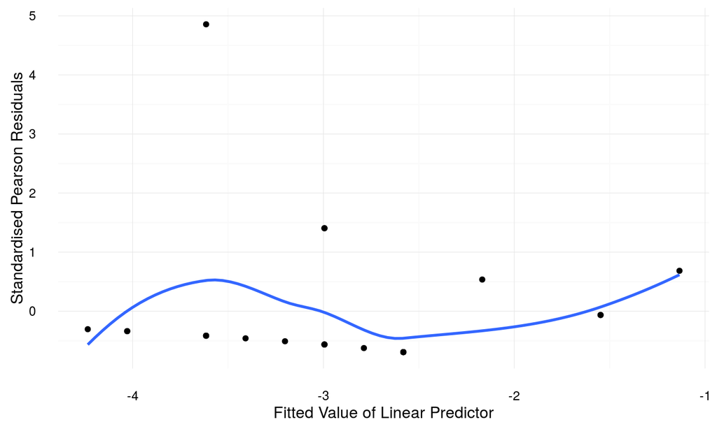

## Resiudal Plots

- Residual plots are seldom used for logistic regression.
  - In the binary case they are very hard to intepret.
- This is alo related to the historical use of logistic models as predictive models. In industry they tend to be assessed on their predictive accuracy.

## Cook's Distance plot

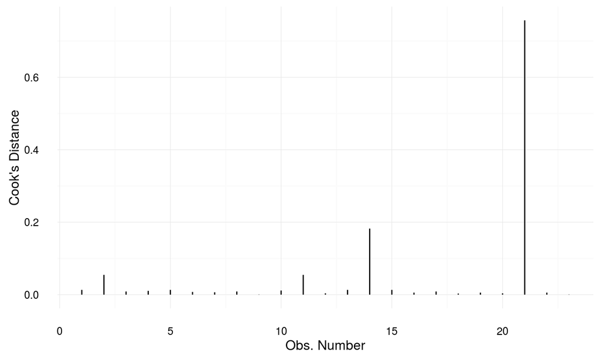

## Performance

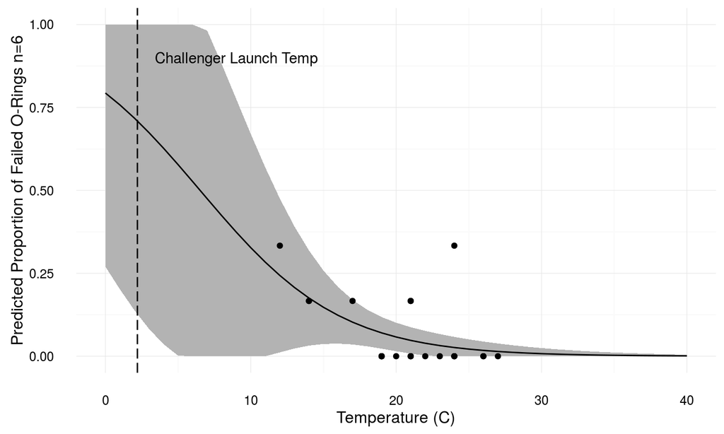

## Intepretation: Multiplicative effect

```
##          term   estimate  std.error  statistic    p.value
## 1 (Intercept)  1.3466136 1.59817973  0.8425921 0.39945663
## 2        Temp -0.2067269 0.08651668 -2.3894450 0.01687385
```

Using \(\frac{\hat{\pi}}{1-\hat{\pi}} = \exp(\hat{\eta_{i}})\):

```r
1/exp(-0.2067+c(-2*0.0865, 2*0.0865))
```

```
## [1] 1.461846 1.034274
```

We can claim: According to our model, we are 95% confident that for each degree decrease in air temperature the odds of booster rocket o-ring failure increase by 1.03 to 1.46 times.

## Intepretation: Proportion estimate

```
##          term   estimate  std.error  statistic    p.value
## 1 (Intercept)  1.3466136 1.59817973  0.8425921 0.39945663
## 2        Temp -0.2067269 0.08651668 -2.3894450 0.01687385
```

```r
eta = 1.3466 + (2.22 * -0.2067)
p = exp(eta) / (1+exp(eta))
p
```

```
## [1] 0.7084207
```

Furthermore we note that given the launch day temperature of 2.2 dergess, our model predicts a 70% rocket booster O-ring failure rate with no sensible estimates of uncertainty available due to the temperature being well outside the range of the test data.